# The MNIST dataset

The MNIST database of handwritten digits, available at [Yann Lecun web site](http://yann.lecun.com/exdb/mnist), has a training set of 60,000 examples, and a test set of 10,000 examples. It is a subset of a larger set available from NIST.

The digits have been size-normalized and centered in a fixed-size image. It is a good database for people who want to try learning techniques and pattern recognition methods on real-world data while spending minimal efforts on preprocessing and formatting.

Table of contents

### MNIST numbers

| **training images:** | 60000 |
| --- | --- |
| **test images:** | 10000 |
| **image pixels:** | 28x28 |
| **image format:** | raw vector of 784 elements |
|  | encoding 0-255 |

### MNIST with python

###### Get the dataset and the python functionalities

To can obtain and use it in python in two steps:

- Install python-mnist:

```
sudo pip install python_mnist
```

- Download the files of the dataset in a folder called data. You can find them here. Just unzip them in the same directory of your python scripts.

###### Using the dataset in python

Now we can use the dataset in a readable way by using the load_training and load_testing methods of the MNIST object:

```python
# import the mnist class
from mnist import MNIST

# init with the 'data' dir
mndata = MNIST('./data')

# Load data
mndata.load_training()
mndata.load_testing()

# The number of pixels per side of all images
img_side = 28

# Each input is a raw vector.
# The number of units of the network
# corresponds to the number of input elements
n_mnist_pixels = img_side*img_side
```

Below, as an example, we take the first ten samples from the training set and plot them:

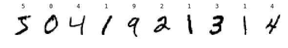

```python
%matplotlib inline
from pylab import *

# Define the number of samples to take
num_samples = 10

# create a figure where we will store all samples
figure(figsize=(10,1))

# Iterate over samples indices
for sample in xrange(num_samples) :

    # The image corresponding to the 'sample' index
    img = mndata.train_images[sample]

    # The label of the image
    label = mndata.train_labels[sample]

    # The image is stored as a rolled vector,
    # we have to roll it back in a matrix
    aimg = array(img).reshape(img_side, img_side)

    # Open a subplot for each sample
    subplot(1, num_samples, sample+1)

    # The corresponding digit is the title of the plot
    title(label)

    # We use imshow to plot the matrix of pixels
    imshow(aimg, interpolation = 'none',
        aspect = 'auto', cmap = cm.binary)
    axis("off")

show()
```

Next cell is just for styling

```python
from IPython.core.display import HTML
def css_styling():
    styles = open("../style/ipybn.css", "r").read()
    return HTML(styles)
css_styling()
```